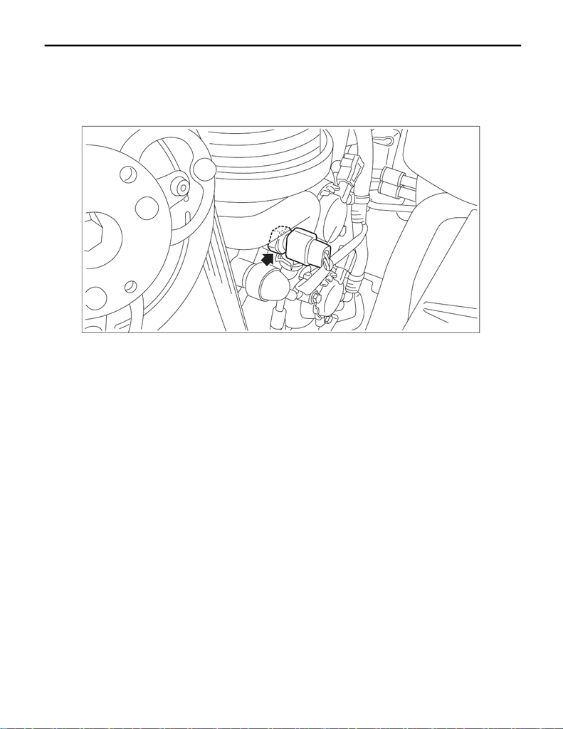

FU(w/o STI)-96

Engine Oil Temperature Sensor

FUEL INJECTION (FUEL SYSTEMS)

12.Engine Oil Temperature Sensor

A: REMOVAL

1) Disconnect the ground terminal from battery sensor. <Ref. to NT-5, BATTERY, NOTE, Note.>

ature sensor from the chain cover.

B: INSTALLATION

Install in the reverse order of removal.

NOTE:

Use a new gasket.

Tightening torque:

18 N·m (1.8 kgf-m, 13.3 ft-lb)

(A)

FU-07972

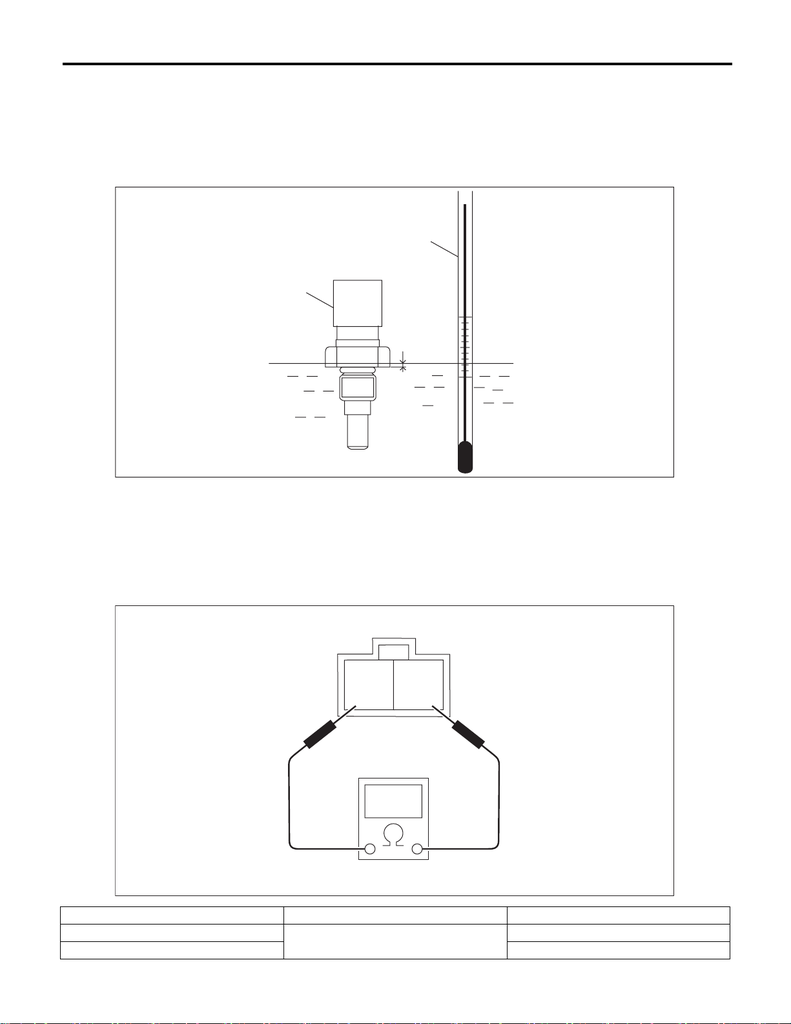

FU(w/o STI)-97

Engine Oil Temperature Sensor

FUEL INJECTION (FUEL SYSTEMS)

C: INSPECTION

1) Check that the engine oil temperature sensor has no deformation, cracks or other damages.

2) Immerse the engine oil temperature sensor and a thermometer in water.

CAUTION:

Take care not to allow water to get into the engine oil temperature sensor connector. Completely re-

move any water inside.

3) Raise water temperature gradually, measure the resistance between the engine oil temperature sensor

terminals when the temperature is 20°C (68°F) and 80°C (176°F).

NOTE:

Agitate the water for even temperature distribution.

1

/

3

Water temperature Terminal No. Standard

20°C (68°F)

1 and 2

Approx. 2.45±0.2 kΩ

80°C (176°F) Approx. 0.318±0.013 kΩ

FU-05949

(A)

(B)

(C)

FU-05950

2

1